# Syntax and Output for Analyses

Ian Ruginski

3/14/2019

This is output and analysis for reproducability for analyses included in the paper, “GPS-use negatively affects environmental learning through spatial transformation abilities,” authored by Ian T. Ruginski, Sarah H. Creem-Regehr, Jeanine K. Stefanucci, and Elizabeth Cashdan.

### Data Cleaning & Loading Packages

Read in the data file. Load library packages.

```r
#loading libraryd packages
library(tidyverse)
library(broom)
library(knitr)
library(kableExtra)
options(digits=2)
library(psych)
library(car)
library(lavaan)
library(tidylog)
library(Hmisc)

#read in data
clean <- read.csv("ian_diss_cleaneddata.csv")
pt <- read.csv("PerspectiveTakingDataRaw.csv")

#cleaning PT data
#NOTE: If a participant leaves an item blank, they should be assigned an angular deviation of 90 degrees for that item (90 represents chance performance, given that the angular deviation can vary from 0 to 180) (this was done when entering data)

#If the angular deviation on any item exceeds 180, it should be subtracted from 360 to determine the smallest deviation possible. This is because the angular deviation between two angles does not exceed 180 degrees.

pt$SOTe1c <- ifelse(pt$SOTe1>=180, 360-pt$SOTe1, pt$SOTe1)
pt$SOTe2c <- ifelse(pt$SOTe2>=180, 360-pt$SOTe2, pt$SOTe2)
pt$SOTe3c <- ifelse(pt$SOTe3>=180, 360-pt$SOTe3, pt$SOTe3)
pt$SOTe4c <- ifelse(pt$SOTe4>=180, 360-pt$SOTe4, pt$SOTe4)
pt$SOTe5c <- ifelse(pt$SOTe5>=180, 360-pt$SOTe5, pt$SOTe5)
pt$SOTe6c <- ifelse(pt$SOTe6>=180, 360-pt$SOTe6, pt$SOTe6)
pt$SOTe7c <- ifelse(pt$SOTe7>=180, 360-pt$SOTe7, pt$SOTe7)
pt$SOTe8c <- ifelse(pt$SOTe8>=180, 360-pt$SOTe8, pt$SOTe8)
pt$SOTe9c <- ifelse(pt$SOTe9>=180, 360-pt$SOTe9, pt$SOTe9)
pt$SOTe10c <- ifelse(pt$SOTe10>=180, 360-pt$SOTe10, pt$SOTe10)
pt$SOTe11c <- ifelse(pt$SOTe11>=180, 360-pt$SOTe11, pt$SOTe11)
pt$SOTe12c <- ifelse(pt$SOTe12>=180, 360-pt$S2Te10, pt$SOTe12)

pt <- select(pt, SOTe1c:SOTe12c) #subset newly coded items
pt$SOTmean <- rowMeans(select(pt, SOTe1c:SOTe12c))

#add PT data to full dataframe
clean <- cbind(clean, pt$SOTmean)
#change names
colnames(clean)[87] <- "SOTmean"

#make aggregate distance/pointing measures
clean$Pointing <- (clean$BetweenRtPt + clean$WithinRtPt) / 2
clean$Distance <- (clean$BetweenDist + clean$WithinDist) / 2

#make GPS variable numeric
clean$GPSuse <- as.numeric(clean$Q14)

#below code writes clean datafile
#write.csv(clean, "ian_diss_cleaneddatawithpt.csv")

#add bidimensional regression cognitive map data
bidim <- read.csv("bidimregression_results.csv")
bidimrsq <- select(bidim, id, r.2) #extract rsquared column only (variance explained in cog maps)
cleanr <- merge(clean, bidimrsq, by="id")#make new dataframe w bidim data

#make inverse scores so that higher means better ability for all variables consistently
cleanr$SOTmeanI <- -cleanr$SOTmean
cleanr$BetweenRtPtI <- -cleanr$BetweenRtPt
cleanr$WithinRtPtI <- -cleanr$WithinRtPt
cleanr$DistanceI <- -cleanr$Distance
```

### Visualizing Distribution of GPS-use, Preliminary Analyses, & Assumptions

In this section we visualize distributions of variables and assess multicollinearity for mental rotation and perspective-taking, which are known to be very highly correlated. We also determine if GPS-use affects spatial transformation and environmental learning variables, to determine if mediation is a possibility apriori before testing our primary hypotheses.

#### Descriptives & correlation matrix

```r
library(moments)

#make APA style Descriptives table
statdesc <- cleanr %>%
  summarise_at(vars(SBtotal, GPSuse, MRT, SOTmean, WithinRtPt:BetweenRtPt,
                    Distance:r.2, Q1, Q4, UTdist),
                    list(~mean(.), ~sd(.), ~skewness(.), ~kurtosis(.)), na.rm=TRUE) %>%
    gather("Variable", "Value") %>%
    separate(Variable, c("Variable", "Statistic"), "_") %>%
    spread("Statistic", "Value") %>%
  select(Variable, mean, sd, skewness, kurtosis) %>%
  arrange(factor(Variable, levels = c("SBtotal", "GPSuse", "MRT", "SOTmean",
                                      "WithinRtPt", "BetweenRtPt",
                                      "Distance", "r.2", "Q1", "Q4", "UTdist")))

kable(statdesc) %>%
  kable_styling(bootstrap_options = c("striped", "hover", "condensed"))
```

| Variable | mean | sd | skewness | kurtosis |
| --- | --- | --- | --- | --- |
| SBtotal | 3.80 | 1.01 | -0.27 | 2.8 |
| GPSuse | 3.38 | 0.94 | -0.24 | 2.7 |
| MRT | 30.48 | 21.80 | 0.04 | 2.6 |
| SOTmean | 35.00 | 23.04 | 0.92 | 3.0 |
| WithinRtPt | 27.89 | 12.19 | 0.44 | 2.8 |
| BetweenRtPt | 45.90 | 12.87 | -0.59 | 2.7 |
| Distance | 134.41 | 52.54 | 1.31 | 5.6 |
| r.2 | 0.49 | 0.26 | 0.09 | 1.9 |
| Q1 | 3.47 | 1.47 | 0.40 | 2.8 |
| Q4 | 3.46 | 1.69 | 1.31 | 4.2 |
| UTdist | 1575.71 | 956.00 | 0.27 | 2.2 |

```r
write.table(format(statdesc, digits=2), file = "statdesc_diss.txt", sep = ",", quote = FALSE, row.names = F)

#correlations
cor.df <- cleanr %>%
  select(SBtotal, GPSuse, MRT, SOTmean, WithinRtPt:BetweenRtPt, Distance:r.2, Q1, Q4, UTdist) %>%
  as.matrix() %>%
  rcorr(type = "spearman")
options(scipen=10)

rcors <- kable(cor.df$r) %>%
  kable_styling(bootstrap_options = c("striped", "hover", "condensed"))
write.table(formatC(cor.df$r, digits=2),
            file = "rcors_diss.txt", sep = ",", quote = FALSE, row.names = T)
rcors
```

|  | SBtotal | GPSuse | MRT | SOTmean | WithinRtPt | BetweenRtPt | Distance | r.2 | Q1 | Q4 | UTdist |
| --- | --- | --- | --- | --- | --- | --- | --- | --- | --- | --- | --- |
| SBtotal | 1.00 | -0.36 | 0.21 | -0.27 | -0.34 | -0.25 | -0.26 | 0.20 | 0.10 | 0.15 | 0.12 |
| GPSuse | -0.36 | 1.00 | -0.32 | 0.26 | 0.20 | 0.08 | 0.21 | -0.16 | -0.08 | 0.00 | -0.05 |
| MRT | 0.21 | -0.32 | 1.00 | -0.53 | -0.23 | -0.12 | -0.24 | 0.20 | -0.03 | 0.02 | 0.14 |
| SOTmean | -0.27 | 0.26 | -0.53 | 1.00 | 0.26 | 0.14 | 0.29 | -0.23 | 0.04 | -0.08 | -0.05 |
| WithinRtPt | -0.34 | 0.20 | -0.23 | 0.26 | 1.00 | 0.55 | 0.58 | -0.56 | 0.14 | -0.03 | -0.07 |
| BetweenRtPt | -0.25 | 0.08 | -0.12 | 0.14 | 0.55 | 1.00 | 0.47 | -0.50 | 0.03 | -0.02 | 0.03 |
| Distance | -0.26 | 0.21 | -0.24 | 0.29 | 0.58 | 0.47 | 1.00 | -0.59 | 0.01 | 0.03 | 0.01 |
| r.2 | 0.20 | -0.16 | 0.20 | -0.23 | -0.56 | -0.50 | -0.59 | 1.00 | -0.10 | -0.04 | -0.05 |
| Q1 | 0.10 | -0.08 | -0.03 | 0.04 | 0.14 | 0.03 | 0.01 | -0.10 | 1.00 | 0.05 | 0.09 |
| Q4 | 0.15 | 0.00 | 0.02 | -0.08 | -0.03 | -0.02 | 0.03 | -0.04 | 0.05 | 1.00 | 0.17 |
| UTdist | 0.12 | -0.05 | 0.14 | -0.05 | -0.07 | 0.03 | 0.01 | -0.05 | 0.09 | 0.17 | 1.00 |

```r
pcors <- kable(cor.df$P) %>%
  kable_styling(bootstrap_options = c("striped", "hover", "condensed"))
pcors
```

|  | SBtotal | GPSuse | MRT | SOTmean | WithinRtPt | BetweenRtPt | Distance | r.2 | Q1 | Q4 | UTdist |
| --- | --- | --- | --- | --- | --- | --- | --- | --- | --- | --- | --- |
| SBtotal | NA | 0.00 | 0.00 | 0.00 | 0.00 | 0.00 | 0.00 | 0.01 | 0.14 | 0.03 | 0.15 |
| GPSuse | 0.00 | NA | 0.00 | 0.00 | 0.00 | 0.25 | 0.00 | 0.02 | 0.25 | 0.98 | 0.55 |
| MRT | 0.00 | 0.00 | NA | 0.00 | 0.00 | 0.10 | 0.00 | 0.01 | 0.69 | 0.81 | 0.09 |
| SOTmean | 0.00 | 0.00 | 0.00 | NA | 0.00 | 0.05 | 0.00 | 0.00 | 0.62 | 0.29 | 0.51 |
| WithinRtPt | 0.00 | 0.00 | 0.00 | 0.00 | NA | 0.00 | 0.00 | 0.00 | 0.04 | 0.71 | 0.36 |
| BetweenRtPt | 0.00 | 0.25 | 0.10 | 0.05 | 0.00 | NA | 0.00 | 0.00 | 0.68 | 0.76 | 0.75 |
| Distance | 0.00 | 0.00 | 0.00 | 0.00 | 0.00 | 0.00 | NA | 0.00 | 0.93 | 0.65 | 0.95 |
| r.2 | 0.01 | 0.02 | 0.01 | 0.00 | 0.00 | 0.00 | 0.00 | NA | 0.17 | 0.55 | 0.53 |
| Q1 | 0.14 | 0.25 | 0.69 | 0.62 | 0.04 | 0.68 | 0.93 | 0.17 | NA | 0.44 | 0.28 |
| Q4 | 0.03 | 0.98 | 0.81 | 0.29 | 0.71 | 0.76 | 0.65 | 0.55 | 0.44 | NA | 0.03 |
| UTdist | 0.15 | 0.55 | 0.09 | 0.51 | 0.36 | 0.75 | 0.95 | 0.53 | 0.28 | 0.03 | NA |

```r
write.table(formatC(cor.df$P, digits=2, format="g"),
            file = "pcors_diss.txt", sep = ",", quote = FALSE, row.names = T)
```

Correlations (r) displayed before p-values for each correlation.

#### Sex differences

```r
cleanr$GenderC <- factor(cleanr$Gender, levels=c("Female", "Male"))

sex.t <- cleanr %>%
  select(SBtotal, GPSuse, MRT,
         SOTmean, WithinRtPt:BetweenRtPt,
         Distance:r.2, Q1, Q4, UTdist) %>%
  map(~tidy(t.test(. ~ cleanr$GenderC))) %>%
  bind_rows() %>%
  mutate(Variable = c("SBtotal", "GPSuse", "MRT", "SOTmean",
                "WithinRtPt", "BetweenRtPt",
                "Distance", "r.2", "Q1", "Q4", "UTdist"))
kable(sex.t) %>%
  kable_styling(bootstrap_options = c("striped", "hover", "condensed"))
```

| estimate | estimate1 | estimate2 | statistic | p.value | parameter | conf.low | conf.high | method | alternative | Variable |
| --- | --- | --- | --- | --- | --- | --- | --- | --- | --- | --- |
| -0.54 | 3.57 | 4.11 | -3.93 | 0.00 | 190 | -0.82 | -0.27 | Welch Two Sample t-test | two.sided | SBtotal |
| 0.37 | 3.53 | 3.16 | 2.77 | 0.01 | 183 | 0.11 | 0.63 | Welch Two Sample t-test | two.sided | GPSuse |
| -16.02 | 23.49 | 39.51 | -5.40 | 0.00 | 172 | -21.88 | -10.16 | Welch Two Sample t-test | two.sided | MRT |
| 14.90 | 41.35 | 26.45 | 4.92 | 0.00 | 194 | 8.93 | 20.88 | Welch Two Sample t-test | two.sided | SOTmean |
| 5.35 | 30.26 | 24.91 | 3.21 | 0.00 | 195 | 2.07 | 8.64 | Welch Two Sample t-test | two.sided | WithinRtPt |
| 1.39 | 46.65 | 45.26 | 0.75 | 0.45 | 176 | -2.27 | 5.06 | Welch Two Sample t-test | two.sided | BetweenRtPt |
| 26.04 | 145.87 | 119.83 | 3.69 | 0.00 | 196 | 12.11 | 39.98 | Welch Two Sample t-test | two.sided | Distance |
| -0.05 | 0.47 | 0.52 | -1.32 | 0.19 | 178 | -0.13 | 0.02 | Welch Two Sample t-test | two.sided | r.2 |
| -0.12 | 3.43 | 3.56 | -0.58 | 0.56 | 166 | -0.55 | 0.30 | Welch Two Sample t-test | two.sided | Q1 |
| 0.21 | 3.55 | 3.34 | 0.87 | 0.38 | 185 | -0.27 | 0.69 | Welch Two Sample t-test | two.sided | Q4 |
| -212.92 | 1483.87 | 1696.79 | -1.35 | 0.18 | 134 | -525.05 | 99.20 | Welch Two Sample t-test | two.sided | UTdist |

```r
sex.d <- cleanr %>%
  select(GenderC, SBtotal, GPSuse, MRT,
         SOTmean, WithinRtPt:BetweenRtPt,
         Distance:r.2, Q1, Q4, UTdist) %>%
  cohen.d(., "GenderC") %>% .$cohen.d

kable(sex.d) %>%
  kable_styling(bootstrap_options = c("striped", "hover", "condensed"))
```

|  | lower | effect | upper |
| --- | --- | --- | --- |
| SBtotal | 0.27 | 0.56 | 0.85 |
| GPSuse | -0.68 | -0.40 | -0.11 |
| MRT | 0.49 | 0.79 | 1.09 |
| SOTmean | -0.98 | -0.68 | -0.39 |
| WithinRtPt | -0.74 | -0.45 | -0.16 |
| BetweenRtPt | -0.39 | -0.11 | 0.17 |
| Distance | -0.80 | -0.51 | -0.22 |
| r.2 | -0.10 | 0.19 | 0.48 |
| Q1 | -0.20 | 0.09 | 0.37 |
| Q4 | -0.41 | -0.13 | 0.16 |
| UTdist | -0.10 | 0.22 | 0.54 |

```r
statdesc.sex <- cleanr %>% filter(GenderC != "NA") %>%
  group_by(GenderC) %>%
  summarise_at(vars(SBtotal, GPSuse, MRT, SOTmean, WithinRtPt:BetweenRtPt,
                    Distance:r.2, Q1, Q4, UTdist),
                    list(~mean(.), ~sd(.)), na.rm=TRUE)

kable(statdesc.sex) %>%
  kable_styling(bootstrap_options = c("striped", "hover", "condensed"))
```

| GenderC | SBtotal_mean | GPSuse_mean | MRT_mean | SOTmean_mean | WithinRtPt_mean | BetweenRtPt_mean | Distance_mean | r.2_mean | Q1_mean | Q4_mean | UTdist_mean | SBtotal_sd | GPSuse_sd | MRT_sd | SOTmean_sd | WithinRtPt_sd | BetweenRtPt_sd | Distance_sd | r.2_sd | Q1_sd | Q4_sd | UTdist_sd |
| --- | --- | --- | --- | --- | --- | --- | --- | --- | --- | --- | --- | --- | --- | --- | --- | --- | --- | --- | --- | --- | --- | --- |
| Female | 3.6 | 3.5 | 23 | 41 | 30 | 47 | 146 | 0.47 | 3.4 | 3.5 | 1484 | 1.01 | 0.93 | 20 | 25 | 13 | 13 | 57 | 0.27 | 1.4 | 1.7 | 902 |
| Male | 4.1 | 3.2 | 40 | 26 | 25 | 45 | 120 | 0.52 | 3.6 | 3.3 | 1697 | 0.93 | 0.93 | 21 | 18 | 10 | 13 | 42 | 0.25 | 1.6 | 1.7 | 1029 |

#### Visualization of GPS use distribution

```r
#lets look at the variable distributions determine estimator... probably have to use MLR due to GPS-use
#get descriptives
describe(cleanr$GPSuse)
```

```
## cleanr$GPSuse
##        n  missing distinct     Info     Mean      Gmd
##      201        0        5      0.9    3.378     1.02
##
## Value          1     2     3     4     5
## Frequency      5    29    73    73    21
## Proportion 0.025 0.144 0.363 0.363 0.104
```

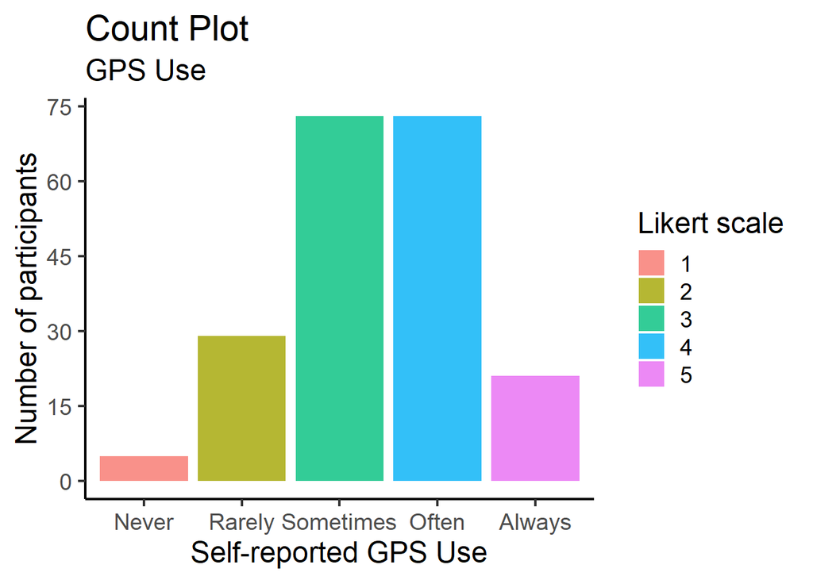

```r
#plot GPS counts as well
theme_set(theme_classic(base_size=18))
ggplot(cleanr, aes(x=as.factor(GPSuse), fill=as.factor(GPSuse))) + geom_bar(alpha=.8) +
  labs(title="Count Plot",
       subtitle="GPS Use",
       x="Self-reported GPS Use") + guides(fill=guide_legend(title="Likert scale")) + scale_y_continuous(breaks=seq(0, 80, 15)) + ylab("Number of participants") + scale_x_discrete(labels=c("1" = "Never", "2" = "Rarely", "3" = "Sometimes", "4" = "Often", "5" = "Always"))
```

```r
#ggsave("GPSuse_distribution.png", width=8, height=6)
```

#### Multicollinearity

Assessing multicollinearity between transformation abilities..

```r
btwmodel <- lm(WithinRtPt ~ MRT + SOTmeanI, cleanr)
vif(btwmodel)
```

```
##      MRT SOTmeanI
##      1.4      1.4
```

#### Preliminary GPS models - predicting outcomes

Preliminary models of GPS-use on outcomes to determine if mediation makes sense apriori.

```r
#GPS preliminary models
model.gps.env <- 'EnvLearn =~ NA*BetweenRtPtI + WithinRtPtI + DistanceI + r.2
EnvLearn ~~ 1*EnvLearn
EnvLearn~GPSuse + Q1 + Q4 + UTdist'
fit.gps.env <- sem(model.gps.env, data = cleanr, missing="FIML", estimator="MLR")
summary(fit.gps.env, standardized=TRUE)
```

```
## lavaan 0.6-3 ended normally after 32 iterations
##
##   Optimization method                           NLMINB
##   Number of free parameters                         16
##
##                                                   Used       Total
##   Number of observations                           157         201
##   Number of missing patterns                         3
##
##   Estimator                                         ML      Robust
##   Model Fit Test Statistic                      21.901      21.064
##   Degrees of freedom                                14          14
##   P-value (Chi-square)                           0.081       0.100
##   Scaling correction factor                                  1.040
##     for the Yuan-Bentler correction (Mplus variant)
##
## Parameter Estimates:
##
##   Information                                 Observed
##   Observed information based on                Hessian
##   Standard Errors                   Robust.huber.white
##
## Latent Variables:
##                    Estimate    Std.Err  z-value  P(>|z|)   Std.lv
##   EnvLearn =~
##     BetweenRtPtI        8.363    0.909    9.203    0.000      8.621
##     WithinRtPtI         9.041    0.725   12.477    0.000      9.320
##     DistanceI          39.116    4.244    9.217    0.000     40.324
##     r.2                 0.218    0.018   12.132    0.000      0.225
##   Std.all
##
##     0.679
##     0.759
##     0.748
##     0.825
##
## Regressions:
##                    Estimate    Std.Err  z-value  P(>|z|)   Std.lv
##   EnvLearn ~
##     GPSuse             -0.220    0.091   -2.405    0.016     -0.213
```

[output cut: 22 more lines]

```
##     0.000
##
## Variances:
##                    Estimate    Std.Err  z-value  P(>|z|)   Std.lv
##    .EnvLearn            1.000                                 0.941
##    .BetweenRtPtI       86.738    9.295    9.331    0.000     86.738
##    .WithinRtPtI        63.847    9.771    6.534    0.000     63.847
##    .DistanceI        1277.671  247.065    5.171    0.000   1277.671
##    .r.2                 0.024    0.005    4.909    0.000      0.024
##   Std.all
##     0.941
##     0.539
##     0.424
##     0.440
##     0.320
```

```r
model.gps.mrt <- '
MRT~GPSuse + Q1 + Q4 + UTdist'
fit.gps.mrt <- sem(model.gps.mrt, data = cleanr,missing="FIML", estimator='MLR')
summary(fit.gps.mrt, standardized=TRUE)
```

```
## lavaan 0.6-3 ended normally after 39 iterations
##
##   Optimization method                           NLMINB
##   Number of free parameters                          6
##
##                                                   Used       Total
##   Number of observations                           157         201
##   Number of missing patterns                         2
##
##   Estimator                                         ML      Robust
##   Model Fit Test Statistic                       0.000       0.000
##   Degrees of freedom                                 0           0
##   Scaling correction factor                                     NA
##     for the Yuan-Bentler correction (Mplus variant)
##
## Parameter Estimates:
##
##   Information                                 Observed
##   Observed information based on                Hessian
##   Standard Errors                   Robust.huber.white
##
## Regressions:
##                    Estimate    Std.Err  z-value  P(>|z|)   Std.lv
##   MRT ~
##     GPSuse             -7.324    1.849   -3.961    0.000     -7.324
##     Q1                 -0.659    1.209   -0.545    0.586     -0.659
##     Q4                  0.476    0.841    0.566    0.571      0.476
##     UTdist              0.002    0.002    1.222    0.222      0.002
##   Std.all
##
##    -0.303
##    -0.044
##     0.035
##     0.097
##
## Intercepts:
##                    Estimate    Std.Err  z-value  P(>|z|)   Std.lv
##    .MRT                51.804    8.632    6.002    0.000     51.804
##   Std.all
##     2.361
##
## Variances:
##                    Estimate    Std.Err  z-value  P(>|z|)   Std.lv
##    .MRT               429.612   48.413    8.874    0.000    429.612
##   Std.all
##     0.892
```

```r
model.gps.pt <- '
SOTmean~GPSuse + Q1 + Q4 + UTdist'
fit.gps.pt <- sem(model.gps.pt, data = cleanr,missing="FIML", estimator='MLR')
summary(fit.gps.pt, standardized=TRUE)
```

```
## lavaan 0.6-3 ended normally after 35 iterations
##
##   Optimization method                           NLMINB
##   Number of free parameters                          6
##
##                                                   Used       Total
##   Number of observations                           157         201
##   Number of missing patterns                         2
##
##   Estimator                                         ML      Robust
##   Model Fit Test Statistic                       0.000       0.000
##   Degrees of freedom                                 0           0
##   Scaling correction factor                                     NA
##     for the Yuan-Bentler correction (Mplus variant)
##
## Parameter Estimates:
##
##   Information                                 Observed
##   Observed information based on                Hessian
##   Standard Errors                   Robust.huber.white
##
## Regressions:
##                    Estimate    Std.Err  z-value  P(>|z|)   Std.lv
##   SOTmean ~
##     GPSuse              6.010    1.862    3.228    0.001      6.010
##     Q1                  1.718    1.145    1.500    0.134      1.718
##     Q4                 -0.662    1.071   -0.618    0.537     -0.662
##     UTdist             -0.001    0.002   -0.703    0.482     -0.001
##   Std.all
##
##     0.240
##     0.111
##    -0.047
##    -0.053
##
## Intercepts:
##                    Estimate    Std.Err  z-value  P(>|z|)   Std.lv
##    .SOTmean            13.398    9.275    1.445    0.149     13.398
##   Std.all
##     0.590
##
## Variances:
##                    Estimate    Std.Err  z-value  P(>|z|)   Std.lv
##    .SOTmean           476.037   52.662    9.039    0.000    476.037
##   Std.all
##     0.924
```

```r
model.gps.mob <- '
GPSuse~Q1 + Q4+UTdist'
fit.gps.mob <- sem(model.gps.mob, data = cleanr,missing="FIML", estimator='MLR')
summary(fit.gps.mob, standardized=TRUE)
```

```
## lavaan 0.6-3 ended normally after 17 iterations
##
##   Optimization method                           NLMINB
##   Number of free parameters                          5
##
##                                                   Used       Total
##   Number of observations                           157         201
##   Number of missing patterns                         1
##
##   Estimator                                         ML      Robust
##   Model Fit Test Statistic                       0.000       0.000
##   Degrees of freedom                                 0           0
##   Scaling correction factor                                     NA
##     for the Yuan-Bentler correction (Mplus variant)
##
## Parameter Estimates:
##
##   Information                                 Observed
##   Observed information based on                Hessian
##   Standard Errors                   Robust.huber.white
##
## Regressions:
##                    Estimate    Std.Err  z-value  P(>|z|)   Std.lv
##   GPSuse ~
##     Q1                  0.015    0.053    0.283    0.778      0.015
##     Q4                 -0.001    0.037   -0.020    0.984     -0.001
##     UTdist             -0.000    0.000   -0.647    0.518     -0.000
##   Std.all
##
##     0.024
##    -0.001
##    -0.051
##
## Intercepts:
##                    Estimate    Std.Err  z-value  P(>|z|)   Std.lv
##    .GPSuse              3.332    0.259   12.851    0.000      3.332
##   Std.all
##     3.671
##
## Variances:
##                    Estimate    Std.Err  z-value  P(>|z|)   Std.lv
##    .GPSuse              0.821    0.088    9.341    0.000      0.821
##   Std.all
##     0.997
```

### Measurement Model

Assesing fit for the measurement model of the visual environmental learning latent factor.

```r
model.measurement <- 'EnvLearn =~ NA*BetweenRtPt + WithinRtPt + r.2 + Distance
EnvLearn ~~ 1*EnvLearn'
fit.measurement <- sem(model.measurement, data = cleanr, missing="FIML", estimator="ML")
summary(fit.measurement, fit.measures = TRUE, standardized=TRUE)
```

```
## lavaan 0.6-3 ended normally after 23 iterations
##
##   Optimization method                           NLMINB
##   Number of free parameters                         12
##
##                                                   Used       Total
##   Number of observations                           200         201
##   Number of missing patterns                         2
##
##   Estimator                                         ML
##   Model Fit Test Statistic                       3.338
##   Degrees of freedom                                 2
##   P-value (Chi-square)                           0.188
##
## Model test baseline model:
##
##   Minimum Function Test Statistic              272.573
##   Degrees of freedom                                 6
##   P-value                                        0.000
##
## User model versus baseline model:
##
##   Comparative Fit Index (CFI)                    0.995
##   Tucker-Lewis Index (TLI)                       0.985
##
## Loglikelihood and Information Criteria:
##
##   Loglikelihood user model (H0)              -2534.860
##   Loglikelihood unrestricted model (H1)      -2533.191
##
##   Number of free parameters                         12
##   Akaike (AIC)                                5093.721
##   Bayesian (BIC)                              5133.301
##   Sample-size adjusted Bayesian (BIC)         5095.283
##
## Root Mean Square Error of Approximation:
##
##   RMSEA                                          0.058
##   90 Percent Confidence Interval          0.000  0.163
##   P-value RMSEA <= 0.05                          0.338
```

[output cut: 19 more lines]

```
## Intercepts:
##                    Estimate  Std.Err  z-value  P(>|z|)   Std.lv  Std.all
##    .BetweenRtPt      45.902    0.908   50.560    0.000   45.902    3.575
##    .WithinRtPt       27.894    0.860   32.443    0.000   27.894    2.294
##    .r.2               0.487    0.019   25.741    0.000    0.487    1.835
##    .Distance        134.409    3.706   36.267    0.000  134.409    2.564
##     EnvLearn          0.000                               0.000    0.000
##
## Variances:
##                    Estimate  Std.Err  z-value  P(>|z|)   Std.lv  Std.all
##     EnvLearn          1.000                               1.000    1.000
##    .BetweenRtPt      86.941   10.793    8.055    0.000   86.941    0.527
##    .WithinRtPt       62.404    9.123    6.840    0.000   62.404    0.422
##    .r.2               0.027    0.004    6.333    0.000    0.027    0.387
##    .Distance       1365.350  176.155    7.751    0.000 1365.350    0.497
```

```r
#fits pretty well & all observed vars load
```

### Structural Equation Models and Model Comparison

#### Model 1: Mental rotation does not predict perspective taking

```r
#model 1: less saturated (no path from MRT to PT)
model.lesssat <- 'EnvLearn =~ NA*BetweenRtPtI + WithinRtPtI + DistanceI + r.2
SOTmeanI ~ GPSuse + 0*MRT + SBtotal
MRT ~ GPSuse + SBtotal
GPSuse ~ SBtotal
EnvLearn ~ MRT + SOTmeanI + GPSuse + SBtotal
EnvLearn ~~ 1*EnvLearn'
fit.lesssat <- sem(model.lesssat, data = cleanr, estimator="MLR", missing="FIML")
summary(fit.lesssat, fit.measures=TRUE, standardized=TRUE)
```

```
## lavaan 0.6-3 ended normally after 95 iterations
##
##   Optimization method                           NLMINB
##   Number of free parameters                         27
##
##   Number of observations                           201
##   Number of missing patterns                         4
##
##   Estimator                                         ML      Robust
##   Model Fit Test Statistic                      67.835      72.027
##   Degrees of freedom                                15          15
##   P-value (Chi-square)                           0.000       0.000
##   Scaling correction factor                                  0.942
##     for the Yuan-Bentler correction (Mplus variant)
##
## Model test baseline model:
##
##   Minimum Function Test Statistic              458.029     467.503
##   Degrees of freedom                                28          28
##   P-value                                        0.000       0.000
##
## User model versus baseline model:
##
##   Comparative Fit Index (CFI)                    0.877       0.870
##   Tucker-Lewis Index (TLI)                       0.771       0.758
##
##   Robust Comparative Fit Index (CFI)                         0.875
##   Robust Tucker-Lewis Index (TLI)                            0.767
##
## Loglikelihood and Information Criteria:
##
##   Loglikelihood user model (H0)              -4552.808   -4552.808
##   Scaling correction factor                                  1.016
##     for the MLR correction
##   Loglikelihood unrestricted model (H1)      -4518.891   -4518.891
##   Scaling correction factor                                  0.989
##     for the MLR correction
##
##   Number of free parameters                         27          27
##   Akaike (AIC)                                9159.617    9159.617
```

[output cut: 53 more lines]

```
##    .SOTmeanI        -36.973    9.497   -3.893    0.000  -36.973   -1.609
##    .MRT              40.300    9.578    4.207    0.000   40.300    1.854
##    .GPSuse            4.731    0.232   20.415    0.000    4.731    5.038
##    .EnvLearn          0.000                               0.000    0.000
##
## Variances:
##                    Estimate  Std.Err  z-value  P(>|z|)   Std.lv  Std.all
##    .EnvLearn          1.000                               0.795    0.795
##    .BetweenRtPtI     89.166    9.808    9.091    0.000   89.166    0.545
##    .WithinRtPtI      57.871    8.499    6.809    0.000   57.871    0.395
##    .DistanceI      1338.378  225.636    5.932    0.000 1338.378    0.491
##    .r.2               0.029    0.005    6.472    0.000    0.029    0.423
##    .SOTmeanI        460.394   44.419   10.365    0.000  460.394    0.872
##    .MRT             421.360   39.823   10.581    0.000  421.360    0.892
##    .GPSuse            0.754    0.074   10.191    0.000    0.754    0.855
```

#### Model 2: Perspective-taking mediates the effect of mental rotation on environmental learning

```r
#model 2: more saturated (path from MRT to PT)
model.moresat <- 'EnvLearn =~ NA*BetweenRtPtI + WithinRtPtI + DistanceI + r.2
SOTmeanI ~ GPSuse + MRT + SBtotal
MRT ~ a*GPSuse + SBtotal
GPSuse ~ SBtotal
EnvLearn ~ MRT + SOTmeanI + GPSuse + SBtotal
EnvLearn ~~ 1*EnvLearn'
fit.moresat <- sem(model.moresat, data = cleanr, estimator="MLR", missing="FIML")
summary(fit.moresat, fit.measures=TRUE, standardized=TRUE)
```

```
## lavaan 0.6-3 ended normally after 93 iterations
##
##   Optimization method                           NLMINB
##   Number of free parameters                         28
##
##   Number of observations                           201
##   Number of missing patterns                         4
##
##   Estimator                                         ML      Robust
##   Model Fit Test Statistic                      17.308      18.203
##   Degrees of freedom                                14          14
##   P-value (Chi-square)                           0.240       0.198
##   Scaling correction factor                                  0.951
##     for the Yuan-Bentler correction (Mplus variant)
##
## Model test baseline model:
##
##   Minimum Function Test Statistic              458.029     467.503
##   Degrees of freedom                                28          28
##   P-value                                        0.000       0.000
##
## User model versus baseline model:
##
##   Comparative Fit Index (CFI)                    0.992       0.990
##   Tucker-Lewis Index (TLI)                       0.985       0.981
##
##   Robust Comparative Fit Index (CFI)                         0.991
##   Robust Tucker-Lewis Index (TLI)                            0.981
##
## Loglikelihood and Information Criteria:
##
##   Loglikelihood user model (H0)              -4527.545   -4527.545
##   Scaling correction factor                                  1.008
##     for the MLR correction
##   Loglikelihood unrestricted model (H1)      -4518.891   -4518.891
##   Scaling correction factor                                  0.989
##     for the MLR correction
##
##   Number of free parameters                         28          28
##   Akaike (AIC)                                9111.089    9111.089
```

[output cut: 53 more lines]

```
##    .SOTmeanI        -56.440    8.367   -6.746    0.000  -56.440   -2.456
##    .MRT              39.817    9.567    4.162    0.000   39.817    1.832
##    .GPSuse            4.731    0.232   20.415    0.000    4.731    5.038
##    .EnvLearn          0.000                               0.000    0.000
##
## Variances:
##                    Estimate  Std.Err  z-value  P(>|z|)   Std.lv  Std.all
##    .EnvLearn          1.000                               0.782    0.782
##    .BetweenRtPtI     89.200    9.817    9.086    0.000   89.200    0.541
##    .WithinRtPtI      57.828    8.499    6.804    0.000   57.828    0.391
##    .DistanceI      1338.180  225.671    5.930    0.000 1338.180    0.487
##    .r.2               0.029    0.005    6.476    0.000    0.029    0.419
##    .SOTmeanI        356.681   35.024   10.184    0.000  356.681    0.675
##    .MRT             421.308   39.816   10.581    0.000  421.308    0.892
##    .GPSuse            0.754    0.074   10.191    0.000    0.754    0.855
```

#### Comparison of Models 1 & 2

Though model 2 appears to fit the data better based on some fit indices, we will used an adjusted Satorra-Bentler Chi-squared difference test to explicitly compare the two nested models.

```r
lavTestLRT(fit.lesssat, fit.moresat) #if p < .05, model different from data. so we want to keep more saturated model with addtl parameter estimated which in this case is path from MRT to PT
```

|  | Df | AIC | BIC | Chisq | Chisq diff | Df diff | Pr(>Chisq) |
| --- | --- | --- | --- | --- | --- | --- | --- |
| fit.moresat | 14 | 9111 | 9204 | 17 | NA | NA | NA |
| fit.lesssat | 15 | 9160 | 9249 | 68 | 62 | 1 | 3.5e-15 |

We find that the more saturated model (where mental rotation predicts perspective-taking, model 2) more accurately represents the data.

### Testing Mediation by Bootstrapping Indirect Effects

Now that we have selected the best fitting model, we will bootstrap indirect effects. Evidence of mediation is present if the bias-corrected CI does not contain zero for an indirect effect. We will also bootstrap difference tests between some direct and indirect effects to evaluate which variables contribute relatively more to spatial transformation and environmental learning ability outcomes.

```r
set.seed(28) #for reproducability of bootstrapping analyses
model.boot <- 'EnvLearn =~ NA*BetweenRtPtI + WithinRtPtI + DistanceI + r.2
SOTmeanI ~ c*GPSuse + e*MRT + h*SBtotal
MRT ~ a*GPSuse + i*SBtotal
GPSuse ~ f*SBtotal
EnvLearn ~ b*MRT + d*SOTmeanI + g*GPSuse + j*SBtotal
EnvLearn ~~ 1*EnvLearn
#calculate indirect effect. a* is where our predictor predicts the mediating variable.
#b* is where our mediator predicts the final dependent variable.
ab := a*b #Indirect effect of GPS on Spatial Learning through MRT
cd := c*d #Ind of GPS on SL through Perspective Taking
de := d*e #Ind of MRT on SL through Perspective Taking
ae := a*e #Ind of GPS on PT through MRT
aed := a*e*d #Ind of GPS on SL through MRT and PT
diff1 := h - ae #Diff between SBSOD direct on PT and GPS to PT through MRT
diff2 := h - c #Diff between effects of SB and GPS on PT
diff3 := a - i #Diff between effects of SB and GPS on MRT
diff4 := j - aed #Difference between SBSOD direct on SL and Indirect from GPS to SL'
fit.boot <- sem(model.boot, data = cleanr, se="bootstrap", test="bootstrap", bootstrap=2000)
```

Check if bias-corrected confidence intervals of bootstrapped indirect effects contain zero for evidence of mediation. This will also provide values for the difference in effects tests.

```r
#bootstrapping  bias corrected CI's for indirect effects
parest <- parameterEstimates(fit.boot, boot.ci.type = "bca.simple", standardized = TRUE)
#pull out parameters of interest
ind_table <- parest %>%
  select(label,est,std.all,se, ci.lower:ci.upper)
ind_table
```

| label | est | std.all | se | ci.lower | ci.upper |
| --- | --- | --- | --- | --- | --- |
|  | 7.6580 | 0.679 | 0.7368 | 6.31822 | 9.3256 |
|  | 8.1894 | 0.778 | 0.6490 | 7.13420 | 9.7034 |
|  | 31.5344 | 0.714 | 2.9510 | 26.59504 | 38.4721 |
|  | 0.1748 | 0.757 | 0.0150 | 0.14800 | 0.2076 |
| c | -2.2108 | -0.088 | 1.6669 | -5.28663 | 1.2411 |
| e | 0.4889 | 0.469 | 0.0555 | 0.37806 | 0.5972 |
| h | 3.3586 | 0.146 | 1.3739 | 0.65159 | 5.9344 |
| a | -5.9548 | -0.248 | 1.8198 | -9.57546 | -2.3157 |
| i | 2.8111 | 0.127 | 1.5804 | -0.09405 | 6.2496 |
| f | -0.3406 | -0.370 | 0.0591 | -0.45618 | -0.2294 |

[output cut: 22 more lines]

#### Model in alternative direction

Below we test our model 2 in a different direction, demonstrating why we did not test alternative directions in our study, and that we cannot claim causality from our study (the model fit is the same regardless of this direction change).

```r
#model 2b: more saturated, but diff direction (path from transforms to GPS)
#shows that directionality does not matter
model.moresat.altdir <- 'EnvLearn =~ NA*BetweenRtPtI + WithinRtPtI + DistanceI + r.2
SOTmeanI ~ MRT + SBtotal
MRT ~ SBtotal
GPSuse ~ SBtotal + MRT + SOTmeanI
EnvLearn ~ MRT + SOTmeanI + GPSuse + SBtotal
EnvLearn ~~ 1*EnvLearn'
fit.moresat.altdir <- sem(model.moresat.altdir, data = cleanr, estimator="MLR", missing="FIML")
summary(fit.moresat.altdir, fit.measures=TRUE, standardized=TRUE)
```

```
## lavaan 0.6-3 ended normally after 83 iterations
##
##   Optimization method                           NLMINB
##   Number of free parameters                         28
##
##   Number of observations                           201
##   Number of missing patterns                         4
##
##   Estimator                                         ML      Robust
##   Model Fit Test Statistic                      17.308      18.203
##   Degrees of freedom                                14          14
##   P-value (Chi-square)                           0.240       0.198
##   Scaling correction factor                                  0.951
##     for the Yuan-Bentler correction (Mplus variant)
##
## Model test baseline model:
##
##   Minimum Function Test Statistic              458.029     467.503
##   Degrees of freedom                                28          28
##   P-value                                        0.000       0.000
##
## User model versus baseline model:
##
##   Comparative Fit Index (CFI)                    0.992       0.990
##   Tucker-Lewis Index (TLI)                       0.985       0.981
##
##   Robust Comparative Fit Index (CFI)                         0.991
##   Robust Tucker-Lewis Index (TLI)                            0.981
##
## Loglikelihood and Information Criteria:
##
##   Loglikelihood user model (H0)              -4527.545   -4527.545
##   Scaling correction factor                                  1.008
##     for the MLR correction
##   Loglikelihood unrestricted model (H1)      -4518.891   -4518.891
##   Scaling correction factor                                  0.989
##     for the MLR correction
##
##   Number of free parameters                         28          28
##   Akaike (AIC)                                9111.089    9111.089
```

[output cut: 53 more lines]

```
##    .SOTmeanI        -67.400    5.793  -11.634    0.000  -67.400   -2.933
##    .MRT              11.745    5.673    2.070    0.038   11.745    0.540
##    .GPSuse            4.549    0.321   14.158    0.000    4.549    4.844
##    .EnvLearn          0.000                               0.000    0.000
##
## Variances:
##                    Estimate  Std.Err  z-value  P(>|z|)   Std.lv  Std.all
##    .EnvLearn          1.000                               0.782    0.782
##    .BetweenRtPtI     89.200    9.817    9.086    0.000   89.200    0.541
##    .WithinRtPtI      57.828    8.499    6.804    0.000   57.828    0.391
##    .DistanceI      1338.180  225.671    5.930    0.000 1338.180    0.487
##    .r.2               0.029    0.005    6.476    0.000    0.029    0.419
##    .SOTmeanI        360.304   35.320   10.201    0.000  360.304    0.682
##    .MRT             447.841   39.330   11.387    0.000  447.841    0.948
##    .GPSuse            0.702    0.070   10.048    0.000    0.702    0.796
```